# Презентация к лабораторной работе 3

Выполнение

Власов Артем Сергеевич

1132246841@rudn.ru

Российский университет дружбы народов

# Информация

## Докладчик

- Власов Артем Сергеевич
- Студент
- Студент
- Российский университет дружбы народов им. П. Лумумбы
- 1132246841@rudn.ru
- https://vlasovas52.github.io/ru/

# Вводная часть

## Цели и задачи

Получение навыков настройки базовых и специальных правдоступадля групп пользователей в операционной системетипа Linux. 1. Прочитайте справочное описание man по командам chgrp,chmod,getfacl,setfacl. 2. Выполнитедействия по управлению базовыми разрешениями для групп пользователей (раздел 3.3.1). 3. Выполнитедействия по управлению специальными разрешениями для групп пользователей (раздел 3.3.2). 4. Выполните действия по управлению расширенными разрешениями с использованием списков ACLдля групп пользователей (раздел 3.3.3).

# Выполнение лабораторной работы 3

Заходим в учетную запись root и создаем два новых каталога, даем группам main и third права к соответствующей директории и проверяем коректность.

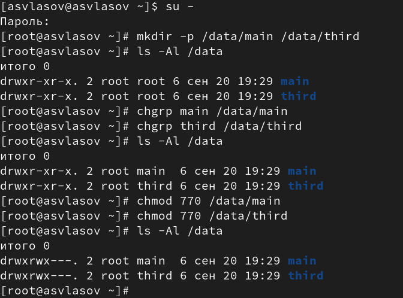

Создание каталогов и прав доступа

Заходим под учетной записью bob и создаем в каталоге main новый файл, видим, что права доступа к этому файлу есть только у пользователя bob так как он состоит в группе main.

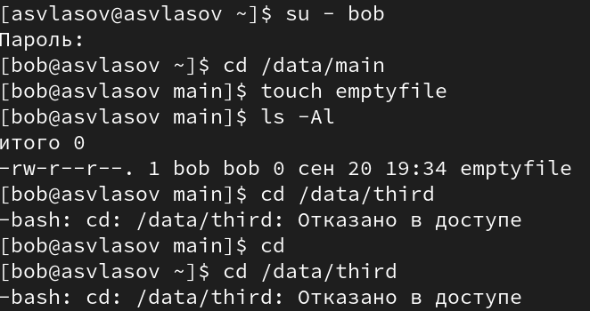

bob

Создаем два новых файла через пользователя alice в каталоге main

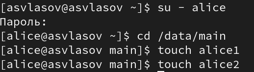

alice new files

Возвращаемся к пользователю bob и пытаемся удалить файлы пользователя alice. Успешно, так как bob имеет полный доступ ко всем файлам директории main.

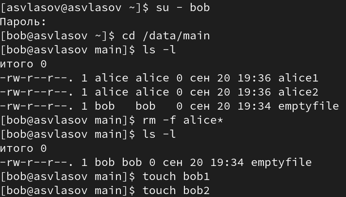

Удаление файлов через bob

Задаем новые права доступа для директории из учетной записи root.

Пробуем создать новые файлы через пользователя alice - успешно. Пробуем удалить файлы созданные учетной записью bob - отказано в доступе.

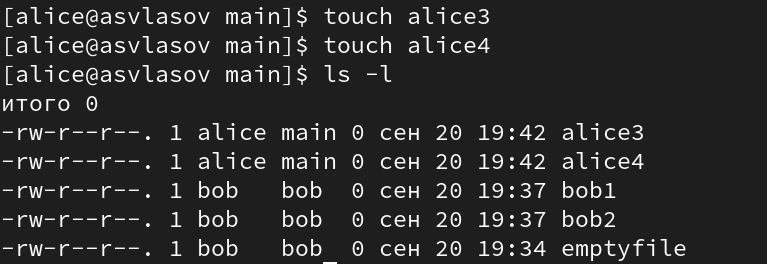

Создание

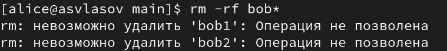

Удаление

Начинаем работу с ACL и задаем новые права доступа нашим директориям.

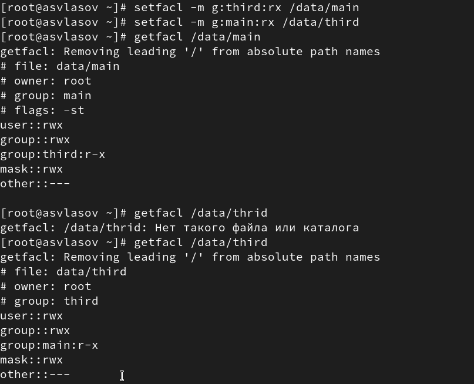

ACL

Создаем новые файлы в наших директориях, видим что они доступны только для чтения.

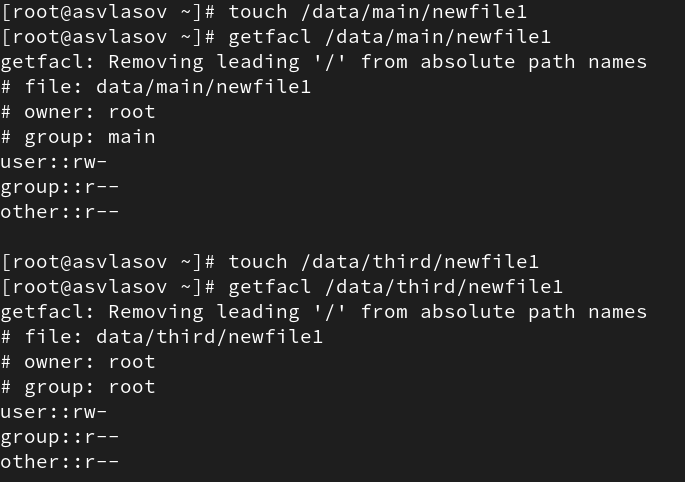

Новые файлы

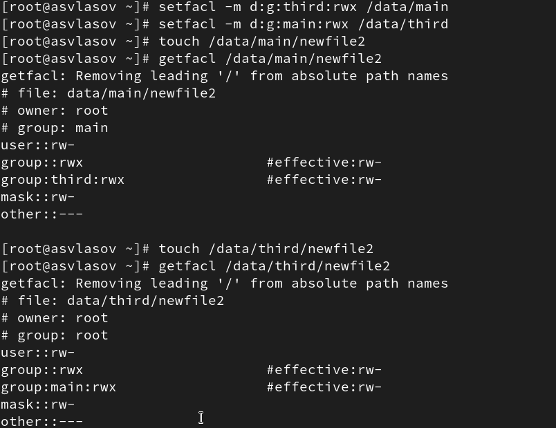

Новые файлы и значения ACL

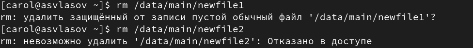

Проверка заданных прав доступа

Теперь пробуем записать текст в новые файлы через carol. Отказано в доступе, так как у файла стоит щзапрет на редактирование для группы third, редактирование второго успешно.

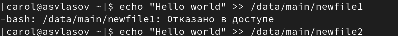

Редактирование файлов

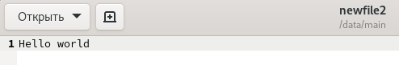

Проверка редактирования

# Выводы

Мы получили навыки настройки базовых и специальных прав доступадля групп пользователей в операционной системетипа Linux.

[figure not shown]